# Training Models to predict London House Prices

Khushi Jaiswal

2025-01-06

# 1 Introduction and learning objectives

The purpose of this project is to build an estimation engine to guide investment decisions in London house market.

I will first build machine learning algorithms (and tune them) to estimate the house prices given variety of information about each property. Then, using my algorithm, I will choose 200 houses to invest in out of about 2000 houses on the market at the moment.

**Learning objectives**

1. Using different data mining algorithms for prediction.
2. Dealing with large data sets
3. Tuning data mining algorithms
4. Interpreting data mining algorithms and deducing importance of variables
5. Using results of data mining algorithms to make business decisions

# 2 Load data

There are two sets of data, i) training data that has the actual prices ii) out of sample data that has the asking prices. I will first Load both data sets.

```r
#read in the data

london_house_prices_2019_training<-read.csv("training_data_assignment_with_prices.csv")
london_house_prices_2019_out_of_sample<-read.csv("test_data_assignment.csv")


#fix data types in both data sets

#fix dates
london_house_prices_2019_training <- london_house_prices_2019_training %>% mutate(date=as.Date(date))
london_house_prices_2019_out_of_sample<-london_house_prices_2019_out_of_sample %>% mutate(date=as.Date(date))
#change characters to factors
london_house_prices_2019_training <- london_house_prices_2019_training %>% mutate_if(is.character,as.factor)
london_house_prices_2019_out_of_sample<-london_house_prices_2019_out_of_sample %>% mutate_if(is.character,as.factor)

#take a quick look at what's in the data
str(london_house_prices_2019_training)
```

```
## 'data.frame':    13998 obs. of  37 variables:
##  $ ID                          : int  2 3 4 5 7 8 9 10 11 12 ...
##  $ date                        : Date, format: "0001-11-20" "0008-08-20" ...
##  $ postcode                    : Factor w/ 12635 levels "BR1 1AB","BR1 1LR",..: 10897 11027 11264 2031 11241 11066 421 9594 9444 873 ...
##  $ property_type               : Factor w/ 4 levels "D","F","S","T": 2 2 3 2 3 2 1 4 4 2 ...
##  $ whether_old_or_new          : Factor w/ 2 levels "N","Y": 1 1 1 1 1 1 1 1 1 1 ...
##  $ freehold_or_leasehold       : Factor w/ 2 levels "F","L": 2 2 1 2 1 2 1 1 1 2 ...
##  $ address1                    : Factor w/ 2825 levels "01-Feb","01-Mar",..: 2503 791 258 788 571 239 269 422 13 278 ...
##  $ address2                    : Factor w/ 434 levels "1","10","101",..: 372 NA NA NA NA NA NA NA NA NA ...
##  $ address3                    : Factor w/ 8543 levels "ABBERTON WALK",..: 6990 6821 3715 2492 4168 2879 3620 5251 6045 6892 ...
##  $ town                        : Factor w/ 133 levels "ABBEY WOOD","ACTON",..: NA NA NA 78 NA NA NA NA NA NA ...
##  $ local_aut                   : Factor w/ 69 levels "ASHFORD","BARKING",..: 36 46 24 36 24 46 65 36 36 17 ...
##  $ county                      : Factor w/ 33 levels "BARKING AND DAGENHAM",..: 22 27 18 25 18 27 5 27 32 8 ...
##  $ postcode_short              : Factor w/ 247 levels "BR1","BR2","BR3",..: 190 194 198 28 198 194 4 169 167 8 ...
##  $ current_energy_rating       : Factor w/ 6 levels "B","C","D","E",..: 4 3 3 4 3 2 4 3 4 2 ...
```

[output cut: 23 more lines]

```r
str(london_house_prices_2019_out_of_sample)
```

```
## 'data.frame':    1999 obs. of  37 variables:
##  $ ID                          : int  14434 12562 8866 10721 1057 1527 13961 12108 9363 1155 ...
##  $ date                        : Date, format: NA NA ...
##  $ postcode                    : logi  NA NA NA NA NA NA ...
##  $ property_type               : Factor w/ 4 levels "D","F","S","T": 1 2 2 3 4 3 2 3 2 4 ...
##  $ whether_old_or_new          : Factor w/ 2 levels "N","Y": 1 1 1 1 1 1 1 1 1 1 ...
##  $ freehold_or_leasehold       : Factor w/ 2 levels "F","L": 1 2 2 1 1 1 2 1 2 1 ...
##  $ address1                    : logi  NA NA NA NA NA NA ...
##  $ address2                    : logi  NA NA NA NA NA NA ...
##  $ address3                    : logi  NA NA NA NA NA NA ...
##  $ town                        : Factor w/ 54 levels "ACTON","ADDISCOMBE",..: NA NA NA NA NA NA NA NA NA NA ...
##  $ local_aut                   : logi  NA NA NA NA NA NA ...
##  $ county                      : logi  NA NA NA NA NA NA ...
##  $ postcode_short              : Factor w/ 221 levels "BR1","BR2","BR3",..: 82 50 37 52 214 150 159 115 175 126 ...
##  $ current_energy_rating       : Factor w/ 6 levels "B","C","D","E",..: 3 2 3 3 4 4 4 3 4 3 ...
```

[output cut: 23 more lines]

```r
#let's do the initial split
library(rsample)
train_test_split <- initial_split(london_house_prices_2019_training, prop = 0.75) #training set contains 75% of the data
# Create the training dataset
train_data <- training(train_test_split)
test_data <- testing(train_test_split)
```

# 3 Visualize data

Now lets Visualize and examine the data. I will be creating plots that will help me to pick out the best varibles to using in our predictive model.

## 3.1 Useful Vis 1 - Distribution of Prices

To get an initial understanding of the price spread, we can create a histogram with distinct bin. The values are heavily right skewed.

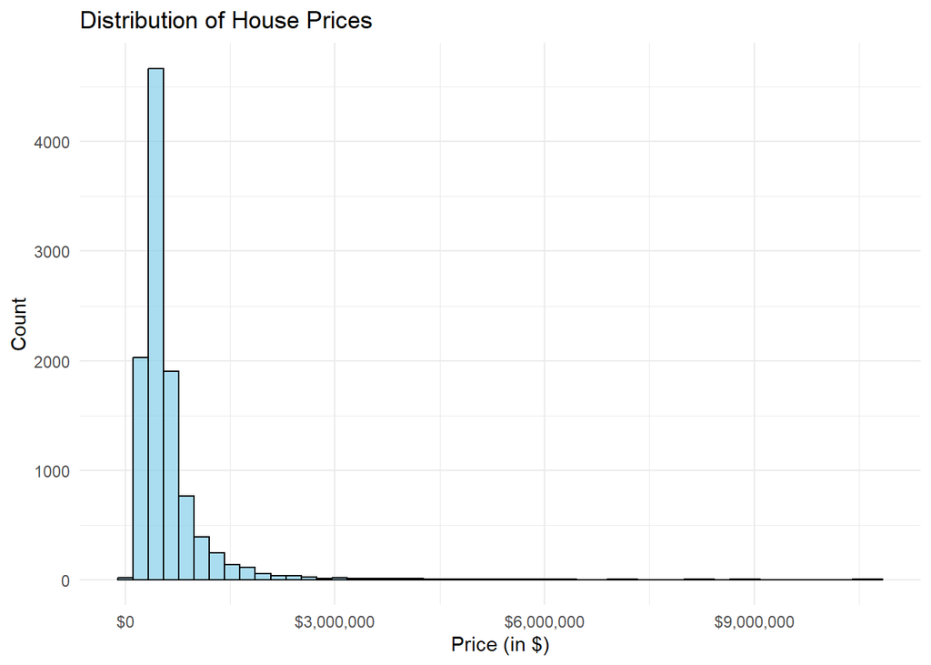

```r
library(ggplot2)
library(ggplot2)

# Plot distribution of price with customized x-axis
ggplot(train_data, aes(x = price)) +
       geom_histogram(bins = 50, fill = "skyblue", color = "black", alpha = 0.7) +
       labs(title = "Distribution of House Prices",
            x = "Price (in $)",
            y = "Count") +
       theme_minimal() +
       scale_x_continuous( labels = scales::dollar_format(scale = 1,
                                                          prefix = "$",
                                                          suffix = "") # Formating labels
        )
```

## 3.2 Useful Vis 2 - Correlation of Numerical Variables

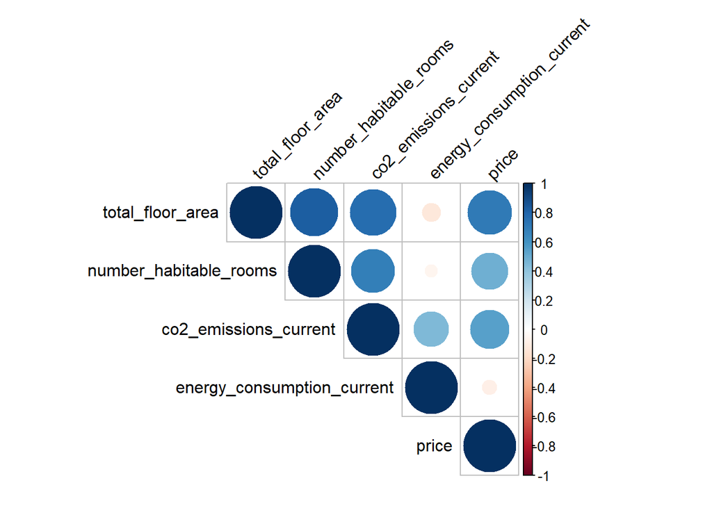

```r
library(corrplot)
# plotting all numerical variables
num_vars <- train_data[, c("total_floor_area",
                           "number_habitable_rooms",
                           "co2_emissions_current",
                           "energy_consumption_current",
                           "price")]
corr_matrix <- cor(num_vars, use = "complete.obs")

# Plot the correlation matrix
corrplot(corr_matrix, method = "circle", type = "upper", tl.col = "black", tl.srt = 45)
```

## Useful Vis 3 - Interaction variables Assessing different interaction variables.

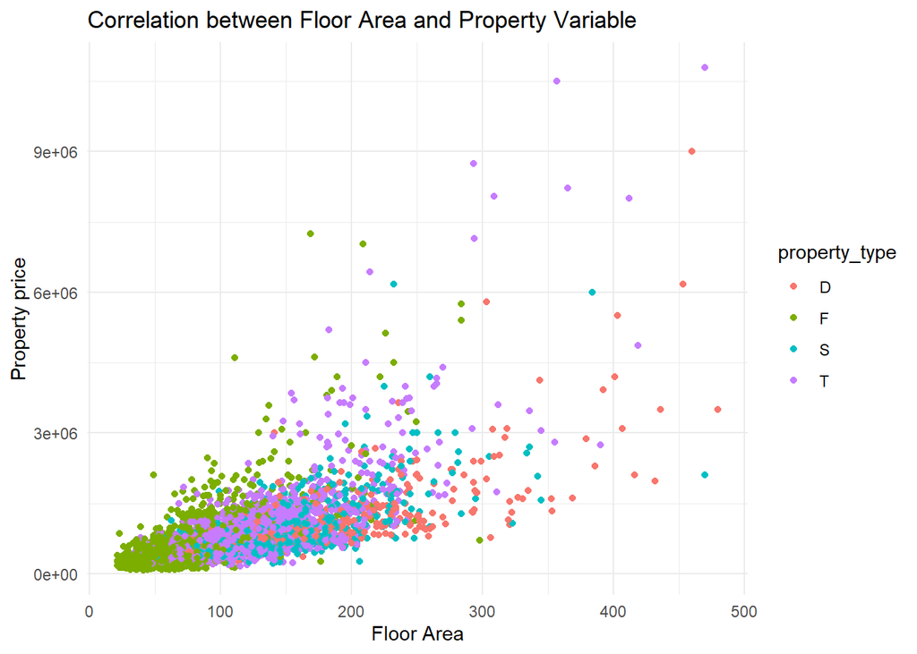

```r
# Scatter plot of floor_area vs property_var
ggplot(train_data, aes(x = total_floor_area, y = price, color = property_type)) +
  geom_point() +  # Add points
  labs(title = "Correlation between Floor Area and Property Variable",
       x = "Floor Area", y = "Property price") +
  theme_minimal()
```

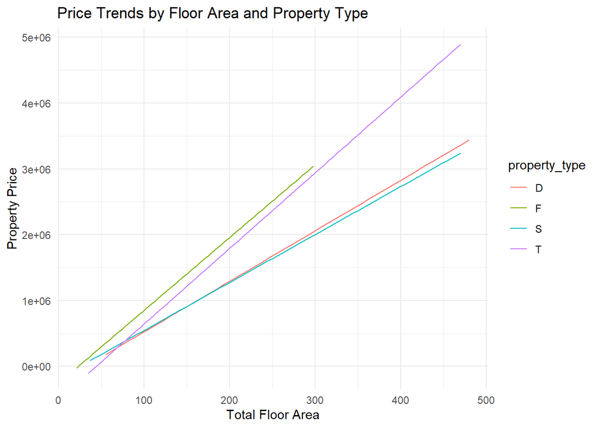

```r
# Line plot of floor_area vs property_var for two property types
ggplot(train_data, aes(x = total_floor_area, y = price, color = property_type, group = property_type)) +
  geom_line(stat = "smooth", method = "lm", se = FALSE) +  # Add smoothed lines for each property_type
  labs(title = "Price Trends by Floor Area and Property Type",
       x = "Total Floor Area", y = "Property Price") +
  theme_minimal()
```

[figure not shown]

```r
# Scatter plot of average income vs London zone, colored by price
ggplot(train_data, aes(x = population, y = price, color=property_type)) +
  geom_point(alpha=0.5) +  # Add points
  labs(title = "Interaction between Average Income and London Zone",
       x = "Average Income", y = "London Zone") +
  scale_y_log10() +
  scale_x_log10() +
  theme_minimal()
```

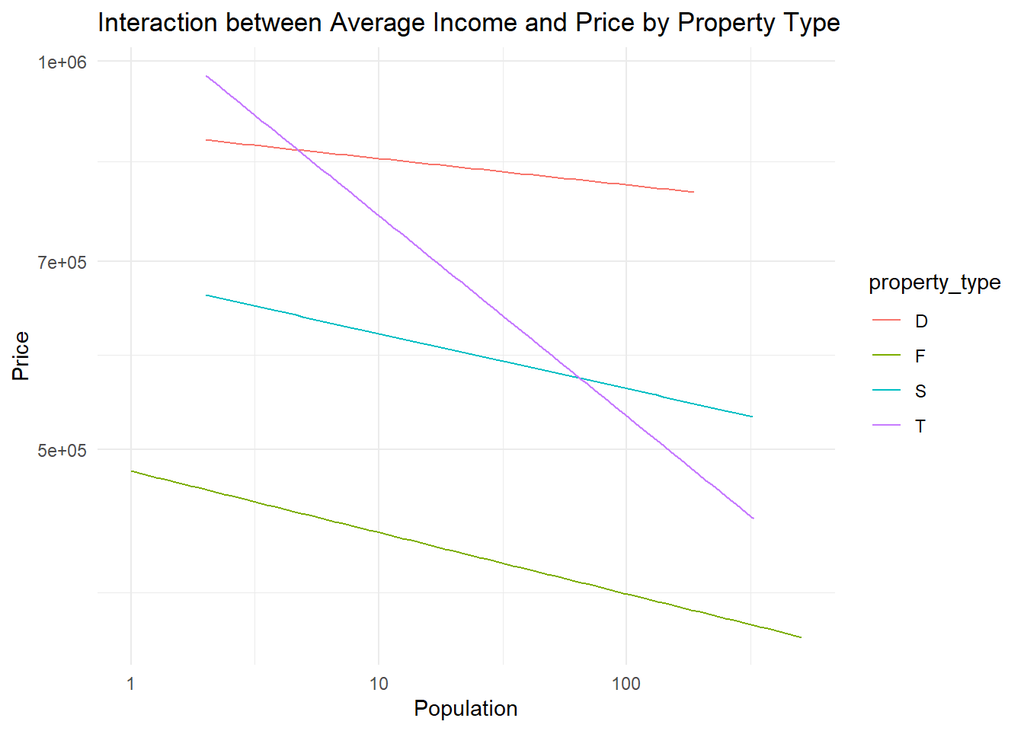

```r
# Line plot of average income vs population, colored by property type
ggplot(train_data, aes(x = population, y = price, color = property_type, group = property_type)) +
  geom_line(stat = "smooth", method = "lm", se = FALSE) +  # Add smoothed lines for each property type
  labs(title = "Interaction between Average Income and Price by Property Type",
       x = "Population", y = "Price") +
  scale_y_log10() +
  scale_x_log10() +
  theme_minimal()
```

[figure not shown]

```r
ggplot(train_data, aes(x = total_floor_area, y = price, color = property_type, group = property_type)) +
  geom_line(stat = "smooth", method = "lm", se = FALSE) +  # Add smoothed lines for each property type
  labs(title = "Interaction between Average Income and Price by Property Type",
       x = "Population", y = "Price") +
  scale_y_log10() +
  scale_x_log10() +
  theme_minimal()
```

[figure not shown]

```r
# Scatter plot of population vs London zone, colored by price
ggplot(train_data, aes(x = population, y = price, color=london_zone)) +
  geom_point(alpha=0.5) +  # Add points
  labs(title = "Interaction between Average Income and London Zone",
       x = "Average Income", y = "London Zone") +
  scale_y_log10() +
  scale_x_log10() +
  theme_minimal()
```

## Useful Vis 4 - correlation between prices & other continuous variables

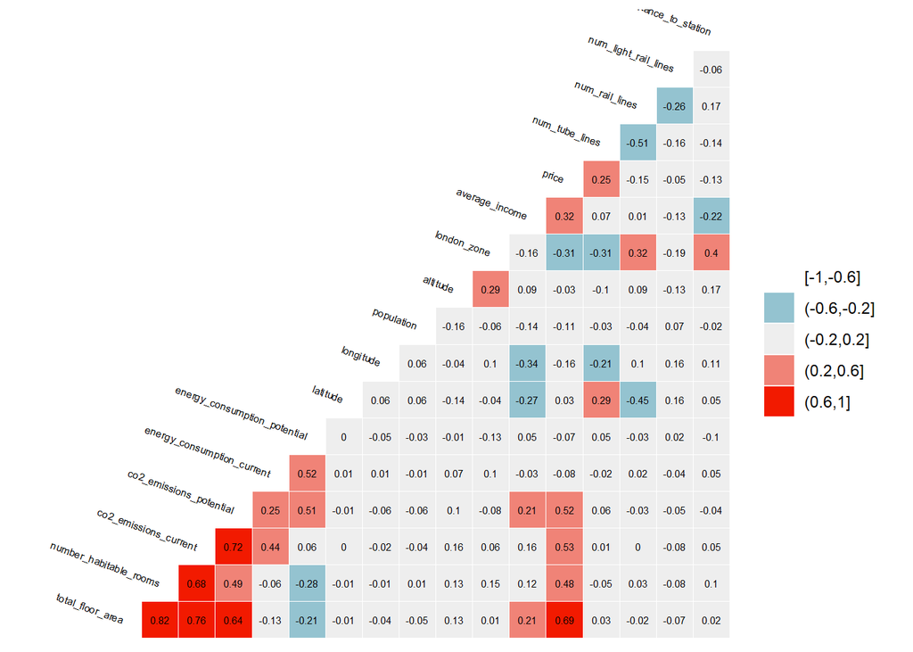

```r
# produce a correlation table using GGally::ggcor()
# this takes a while to plot

library("GGally")
london_house_prices_2019_training %>%
  select(-ID) %>% #keep Y variable last
  ggcorr(method = c("pairwise", "pearson"), layout.exp = 2,label_round=2, label = TRUE,label_size = 2,hjust = 1,nbreaks = 5,size = 2,angle = -20)
```

# 4 Training ML models

Now that we have properly understood the variables in our data set as well as which ones have greater impact on the price and which less, we will be able to use them to train our models.

## 4.1 Linear regression Model

when training the model, I had to keep adding and removing variables to see which variables would give us the best predictions. The commented out models show my journey to get to the final combination of variables.

```r
# #Define control variables
# control <- trainControl (
#     method="cv",
#     number=5,
#     savePredictions = 'all',
#     verboseIter=TRUE)

### ~~~~ ~~~~ ~~~~

# GIVEN MODEL
# model_lm_given<-train(price ~ distance_to_station+
#                               water_company +
#                               property_type +
#                               whether_old_or_new +
#                               freehold_or_leasehold +
#                               latitude +
#                               longitude,
#                       train_data,
#                       method = "lm",
#                       trControl = control
#                       )
# # summary of the results
# summary(model_lm_given)

### ~~~~ ~~~~ ~~~~

# ADDING MORE VARIABLES
# model3_lm <- train(
#     price ~ distance_to_station +
#            water_company +
#            property_type +
#            whether_old_or_new +
#            freehold_or_leasehold +
#            latitude +
#            longitude +
#            total_floor_area +
#            number_habitable_rooms +
#            current_energy_rating +
#            average_income +
#            london_zone +
#            co2_emissions_current +
#            co2_emissions_potential +
#            num_tube_lines +
#            num_rail_lines +
#            num_light_rail_lines +
#            type_of_closest_station +
#            district +
#            average_income +
#            windows_energy_eff +
#            county +
#            energy_consumption_current +
#            energy_consumption_potential +
#            tenure +
#            nearest_station +
#            distance_to_station +
#            postcode_short,
#     train_data,
#     method = "lm",
#     trControl = control
# )
# # Summary of the results
# summary(model3_lm)

### ~~~~ ~~~~ ~~~~

# REMOVING LESS SIGNIFICANT VARIABLES
# model4_lm <- train(
#     price ~ distance_to_station +
#            property_type +
#            freehold_or_leasehold +
#            latitude +
#            longitude +
#            total_floor_area +
#            number_habitable_rooms +
#            average_income +
#            london_zone +
#            co2_emissions_potential +
#            num_light_rail_lines +
#            average_income +
#            energy_consumption_current +
#            energy_consumption_potential +
#            tenure +
#            county,
#     train_data,
#     method = "lm",
#     trControl = control
# )
# # Summary of the results
# summary(model4_lm)


### ~~~~ ~~~~ ~~~~ BEST MODEL ~~~~ ~~~~ ~~~~ ###

#Define control variables
control <- trainControl (
    method="cv",
    number=5,
    savePredictions = 'all',
    verboseIter=FALSE)
# ADDING INTERACTION VARIABLES
model1_lm <- train(
    price ~ water_company +
           property_type +
           freehold_or_leasehold +
           latitude +
           longitude +
           total_floor_area +
           co2_emissions_current +
           average_income +
           london_zone +
           num_tube_lines +
           windows_energy_eff +
           altitude +
           distance_to_station:london_zone +
           property_type:total_floor_area +
           distance_to_station +
           number_habitable_rooms +
           number_habitable_rooms:total_floor_area +
           average_income:london_zone +
           windows_energy_eff:energy_consumption_current +
           freehold_or_leasehold:average_income +
           district,
    train_data,
    method = "lm",
    trControl = control,
    preProcess = c("center", "scale")
)
# Summary of the results
# summary(model1_lm)

### ~~~~ ~~~~ ~~~~ testData ~~~~ ~~~~ ~~~~ ###

predictions <- predict(model1_lm, newdata = test_data) # Generate predictions
actuals <- test_data$price # Compare predictions with actual values

# evaluation metrics
library(Metrics)
rmse_value <- rmse(actuals, predictions)
mae_value <- mae(actuals, predictions)
r2_value <- cor(actuals, predictions)^2
cat("RMSE:", rmse_value, "\n")
```

```
## RMSE: 290107
```

```r
cat("MAE:", mae_value, "\n")
```

```
## MAE: 144862.3
```

```r
cat("R-squared:", r2_value, "\n")
```

```
## R-squared: 0.6741513
```

```r
glimpse(data.frame(
  Model = "Linear Regression",
  RMSE = rmse_value,
  MAE = mae_value,
  R_squared = r2_value
))
```

```
## Rows: 1
## Columns: 4
## $ Model     <chr> "Linear Regression"
## $ RMSE      <dbl> 290107
## $ MAE       <dbl> 144862.3
## $ R_squared <dbl> 0.6741513
```

### 4.1.1 Checking varible importance

The more the importance, the more the variables helps in prediction, hence the better it would be to use it to train our model.

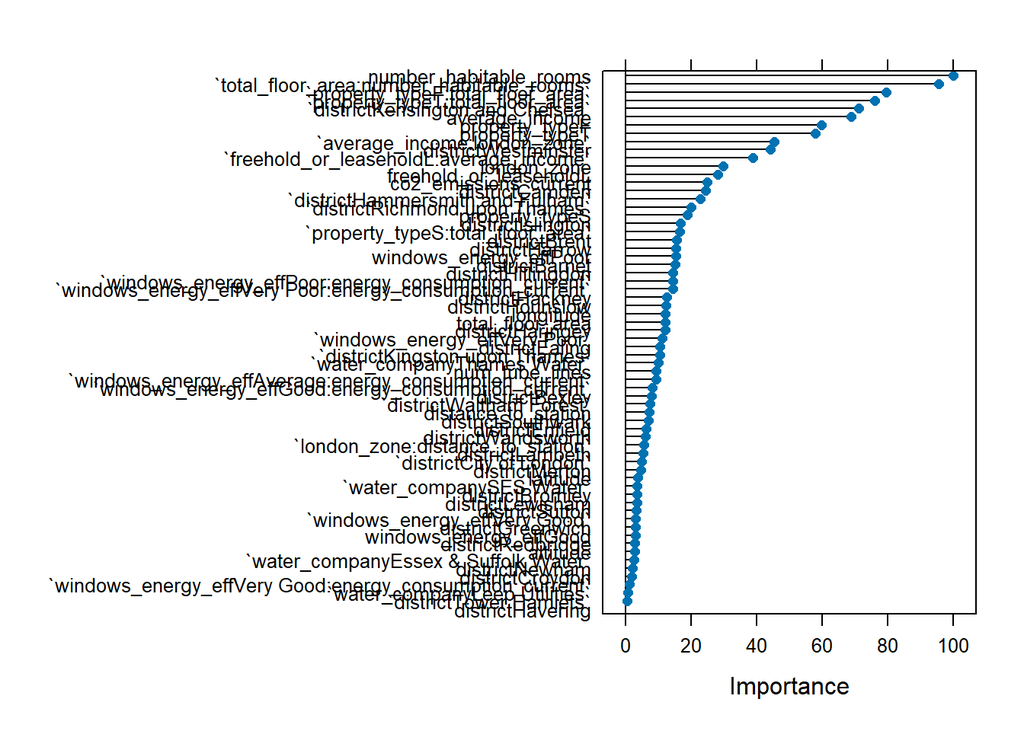

```r
# we can check variable importance as well
importance <- varImp(model1_lm, scale=TRUE)
plot(importance)
```

### 4.1.2 Predict the values in testing and out of sample data

Below I use the predict function to test the performance of the model in testing data and summarize the performance of the linear regression model.

```r
# We can predict the testing values

predictions <- predict(model1_lm,test_data)

lr_results<-data.frame(  RMSE = RMSE(predictions, test_data$price),
                            Rsquare = R2(predictions, test_data$price))

lr_results
```

```
##     RMSE   Rsquare
## 1 290107 0.6741513
```

```r
#We can predict prices for out of sample data the same way
predictions_oos <- predict(model1_lm,london_house_prices_2019_out_of_sample)
# print(predictions_oos)




## out of sample results

# Extract actual and predicted values
actuals <- london_house_prices_2019_out_of_sample$asking_price  # Replace `price` with the actual response variable name
lr_predictions_oos <- predict(model1_lm, london_house_prices_2019_out_of_sample)
# Calculate RMSE
rmse <- sqrt(mean((lr_predictions_oos - actuals)^2))
# Calculate R-squared
rss <- sum((lr_predictions_oos - actuals)^2)  # Residual sum of squares
tss <- sum((actuals - mean(actuals))^2)    # Total sum of squares
r_squared <- 1 - (rss / tss)
# Print results
cat("Linear regression RMSE:", rmse, "\n")
```

```
## Linear regression RMSE: 404307.8
```

```r
cat("Linear regression R-squared:", r_squared, "\n")
```

```
## Linear regression R-squared: 0.6430721
```

## 4.2 Tree model

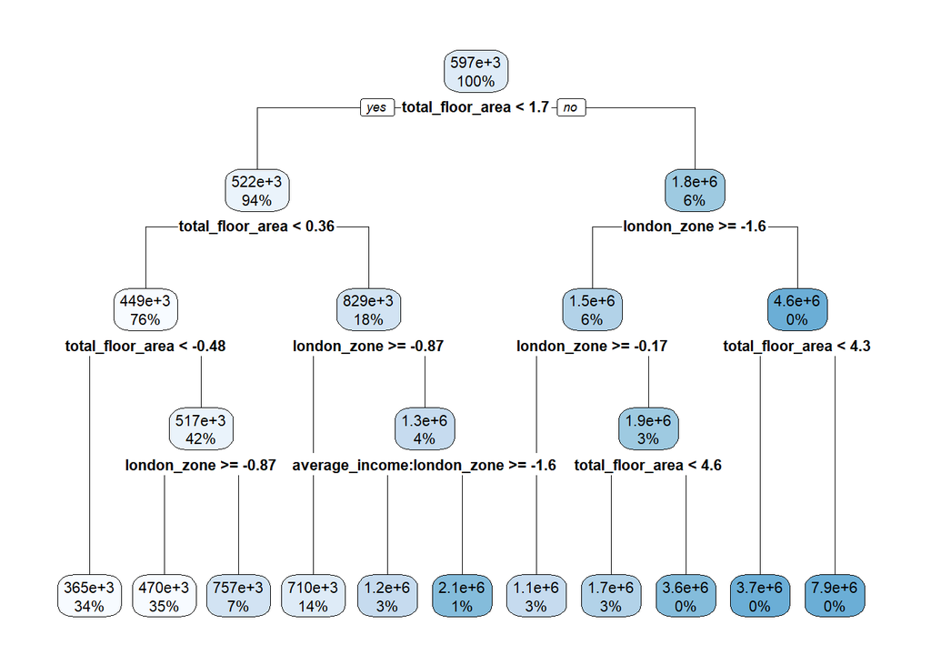

```r
# ## GIVEN MODEL
# model2_tree_given <- train(
#     price ~ distance_to_station +
#            water_company +
#            property_type +
#            whether_old_or_new +
#            latitude +
#            longitude,
#     train_data,
#     method = "rpart",
#     trControl = control,
#     tuneLength = 10
# )

### ~~~~ ~~~~ ~~~~ BEST MODEL ~~~~ ~~~~ ~~~~ ###

# VARS FROM LINEAR REGRESSION
#Define control variables
control <- trainControl (
    method="cv",
    number=5,
    savePredictions = 'all',
    verboseIter=FALSE)
model2_tree <- train(
    price ~ water_company +
           property_type +
           freehold_or_leasehold +
           latitude +
           longitude +
           total_floor_area +
           co2_emissions_current +
           average_income +
           london_zone +
           num_tube_lines +
           windows_energy_eff +
           altitude +
           distance_to_station:london_zone +
           property_type:total_floor_area +
           distance_to_station +
           number_habitable_rooms +
           number_habitable_rooms:total_floor_area +
           average_income:london_zone +
           windows_energy_eff:energy_consumption_current +
           freehold_or_leasehold:average_income +
           district,
    train_data,
    method = "rpart",
    trControl = control,
    tuneLength = 10,
    preProcess = c("center", "scale")
)
# model2_tree$results #tree performance
rpart.plot(model2_tree$finalModel) # final tree
```

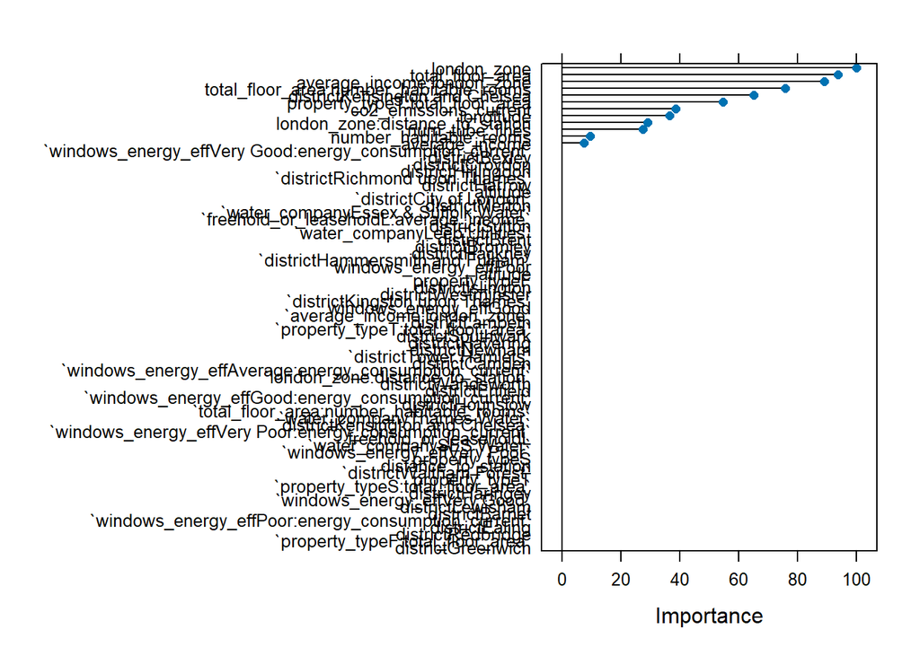

```r
importance <- varImp(model2_tree, scale=TRUE) # variable importance
plot(importance)
```

```r
results <- model2_tree$results[which.min(model2_tree$results$RMSE),]
results
```

```
##            cp     RMSE  Rsquared      MAE   RMSESD RsquaredSD    MAESD
## 1 0.009508042 283207.3 0.7037051 161213.1 8255.786 0.04259227 1926.888
```

```r
### ~~~~ ~~~~ ~~~~ testData ~~~~ ~~~~ ~~~~ ###

predictions <- predict(model2_tree, newdata = test_data) # Generate predictions
actuals <- test_data$price # Compare predictions with actual values

# evaluation metrics
library(Metrics)
rmse_value <- rmse(actuals, predictions)
mae_value <- mae(actuals, predictions)
r2_value <- cor(actuals, predictions)^2
cat("RMSE:", rmse_value, "\n")
```

```
## RMSE: 297905.9
```

```r
cat("MAE:", mae_value, "\n")
```

```
## MAE: 165927.2
```

```r
cat("R-squared:", r2_value, "\n")
```

```
## R-squared: 0.6546343
```

```r
glimpse(data.frame(
  Model = "Tree",
  RMSE = rmse_value,
  MAE = mae_value,
  R_squared = r2_value
))
```

```
## Rows: 1
## Columns: 4
## $ Model     <chr> "Tree"
## $ RMSE      <dbl> 297905.9
## $ MAE       <dbl> 165927.2
## $ R_squared <dbl> 0.6546343
```

## 4.3 KNN Model

KNN can be used for both classification and regression - so I will be using it here.

```r
### ~~~~ ~~~~ ~~~~ BEST MODEL ~~~~ ~~~~ ~~~~ ###

# tuning parameters
tune_grid <- expand.grid(k = 5)
control <- trainControl(method = "cv",
                        number = 10,
                        savePredictions = 'all',
                        verboseIter = FALSE)
# Model 3: Training a KNN model with selected features and interaction terms
model3_knn <- train(
    price ~ water_company +
           property_type +
           freehold_or_leasehold +
           latitude +
           longitude +
           total_floor_area +
           co2_emissions_current +
           average_income +
           london_zone +
           num_tube_lines +
           windows_energy_eff +
           altitude +
           distance_to_station:london_zone +
           property_type:total_floor_area +
           distance_to_station +
           number_habitable_rooms +
           number_habitable_rooms:total_floor_area +
           average_income:london_zone +
           windows_energy_eff:energy_consumption_current +
           freehold_or_leasehold:average_income +
           district,
    data = train_data,
    method = "knn",
    trControl = control,  # Use 10-fold cross-validation
    tuneGrid = tune_grid,  # Number of parameter values train function will try
    preProcess = c("center", "scale")  # Center and scale the data (important for KNN)
)


### ~~~~ ~~~~ ~~~~ testData ~~~~ ~~~~ ~~~~ ###

predictions <- predict(model3_knn, newdata = test_data) # Generate predictions
actuals <- test_data$price # Compare predictions with actual values

# evaluation metrics
library(Metrics)
rmse_value <- rmse(actuals, predictions)
mae_value <- mae(actuals, predictions)
r2_value <- cor(actuals, predictions)^2
cat("RMSE:", rmse_value, "\n")
```

```
## RMSE: 258338.2
```

```r
cat("MAE:", mae_value, "\n")
```

```
## MAE: 119909.6
```

```r
cat("R-squared:", r2_value, "\n")
```

```
## R-squared: 0.7570474
```

```r
glimpse(data.frame(
  Model = "KNN",
  RMSE = rmse_value,
  MAE = mae_value,
  R_squared = r2_value
))
```

```
## Rows: 1
## Columns: 4
## $ Model     <chr> "KNN"
## $ RMSE      <dbl> 258338.2
## $ MAE       <dbl> 119909.6
## $ R_squared <dbl> 0.7570474
```

## 4.4 Random Forest Model

```r
library(randomForest)
```

```r
### ~~~~ ~~~~ ~~~~

# HARDING CODING PARAMETERES

# RForest_Model <- randomForest(
#     price ~ distance_to_station +
#            water_company +
#            property_type +
#            whether_old_or_new +
#            freehold_or_leasehold +
#            latitude +
#            longitude +
#            total_floor_area +
#            number_habitable_rooms +
#            average_income +
#            london_zone +
#            co2_emissions_potential +
#            num_light_rail_lines +
#            energy_consumption_current +
#            energy_consumption_potential +
#            tenure,
#     data = train_data,    # Use the training dataset
#     ntree = 25,           # Number of trees
#     mtry = 3,             # Number of variables to sample at each split
#     maxnodes = 50,        # Limit the number of terminal nodes
#     nodesize = 2,         # Minimum number of observations in each node
#     importance = TRUE     # Calculate feature importance
# )
# print(RForest_Model) # Print the model output
# plot(RForest_Model) # Optional: Plot the error rate and other diagnostics
# varImpPlot(RForest_Model, scale =TRUE) # Optional: Variable Importance plot
# importance <- varImp(RForest_Model, scale=TRUE)
# plot(importance)

### ~~~~ ~~~~ ~~~~

# FINDING THE BEST TUNING PARAMETERS

# Set up cross-validation control
# train_control <- trainControl(
#     method = "cv",              # Cross-validation method
#     number = 2,                 # Number of folds
#     verboseIter = TRUE,         # Show iteration details
#     savePredictions = 'all',    # Save all predictions
#     search = "random"           # Random search for hyperparameters
# )
# # Fit random forest model with random search
# model4_RF_untuned <- train(
#     price ~ water_company +
#            property_type +
#            freehold_or_leasehold +
#            latitude +
#            longitude +
#            total_floor_area +
#            co2_emissions_current +
#            average_income +
#            london_zone +
#            num_tube_lines +
#            windows_energy_eff +
#            altitude +
#            distance_to_station:london_zone +
#            property_type:total_floor_area +
#            distance_to_station +
#            number_habitable_rooms +
#            number_habitable_rooms:total_floor_area +
#            average_income:london_zone +
#            windows_energy_eff:energy_consumption_current +
#            freehold_or_leasehold:average_income +
#            district,
#     data = train_data,
#     method = "ranger",
#     metric = "RMSE",            # Use RMSE for regression
#     trControl = train_control,
#     tuneLength = 10,
#     importance = 'permutation'  # Use permutation importance
# )
# # Print model summary
# print(model4_RF_untuned)
# # Get the best random forest model based on RMSE
# best_randomForest <- knn_fit$results[which.min(model4_RF$results$RMSE),]
# best_randomForest


### ~~~~ ~~~~ ~~~~ BEST MODEL ~~~~ ~~~~ ~~~~ ###

# PAREMETERS HAVE BEEN TUNED

# Set up cross-validation control
train_control <- trainControl(
    method = "cv",              # Cross-validation method
    number = 2,                 # Number of folds
    verboseIter = FALSE,         # Show iteration details
    savePredictions = 'all',    # Save all predictions
    search = "random"           # Random search for hyperparameters
)
# Define the tuning grid for the random forest model
tune_grid_rf <- expand.grid(
    mtry = 39,                  # Hardcoded value for mtry
    min.node.size = 1,          # Hardcoded value for min.node.size
    splitrule = "extratrees"    # Hardcoded value for splitrule
)
# Train the random forest model
model4_RF <- train(
    price ~ water_company +
           property_type +
           freehold_or_leasehold +
           latitude +
           longitude +
           total_floor_area +
           co2_emissions_current +
           average_income +
           london_zone +
           num_tube_lines +
           windows_energy_eff +
           altitude +
           distance_to_station:london_zone +
           property_type:total_floor_area +
           distance_to_station +
           number_habitable_rooms +
           number_habitable_rooms:total_floor_area +
           average_income:london_zone +
           windows_energy_eff:energy_consumption_current +
           freehold_or_leasehold:average_income +
           district,
    data = train_data,
    method = "ranger",
    metric = "RMSE",            # Use RMSE for regression
    trControl = train_control,
    tuneGrid = tune_grid_rf,    # Use the tuning grid
    importance = 'permutation', # Use permutation importance
    preProcess = c("center", "scale")  # Center and scale the data
)
# Print model summary
print(model4_RF)
```

```
## Random Forest
##
## 10498 samples
##    16 predictor
##
## Pre-processing: centered (66), scaled (66)
## Resampling: Cross-Validated (2 fold)
## Summary of sample sizes: 5250, 5248
## Resampling results:
##
##   RMSE      Rsquared   MAE
##   211610.6  0.8401436  98731.07
##
## Tuning parameter 'mtry' was held constant at a value of 39
## Tuning
##  parameter 'splitrule' was held constant at a value of extratrees
##
## Tuning parameter 'min.node.size' was held constant at a value of 1
```

```r
# Get the best random forest model based on RMSE
best_randomForest <- model4_RF$results[which.min(model4_RF$results$RMSE),]
best_randomForest
```

```
##   mtry min.node.size  splitrule     RMSE  Rsquared      MAE   RMSESD RsquaredSD
## 1   39             1 extratrees 211610.6 0.8401436 98731.07 3442.987 0.02331642
##      MAESD
## 1 1020.379
```

```r
### ~~~~ ~~~~ ~~~~ testData ~~~~ ~~~~ ~~~~ ###

predictionsRF <- predict(model4_RF, newdata = test_data) # Generate predictions
actuals <- test_data$price # Compare predictions with actual values

# evaluation metrics
library(Metrics)
rmse_value <- rmse(actuals, predictionsRF)
mae_value <- mae(actuals, predictionsRF)
r2_value <- cor(actuals, predictionsRF)^2
cat("RMSE:", rmse_value, "\n")
```

```
## RMSE: 213098.9
```

```r
cat("MAE:", mae_value, "\n")
```

```
## MAE: 95200.52
```

```r
cat("R-squared:", r2_value, "\n")
```

```
## R-squared: 0.826247
```

```r
glimpse(data.frame(
  Model = "Random Forest",
  RMSE = rmse_value,
  MAE = mae_value,
  R_squared = r2_value
))
```

```
## Rows: 1
## Columns: 4
## $ Model     <chr> "Random Forest"
## $ RMSE      <dbl> 213098.9
## $ MAE       <dbl> 95200.52
## $ R_squared <dbl> 0.826247
```

# 5 Stacking

Now that I have traine 4 models that are giving me satisfactory RMSE’s and RSquared’s, I will be using stacking to ensemble them on top of each other to create a model that will be combining each of the 4 models to produce the best predictions.

```r
library(caret)
library(caretEnsemble)
library(ggplot2)
library(pROC)

# removing NA values
# train_data_new <- na.omit(train_data)




# Train Control with RMSE and R-squared as metrics
my_control <- trainControl(
  method = "cv",                # Cross-validation
  number = 5,                   # 5 folds
  savePredictions = "final",    # Save final predictions
  verboseIter = FALSE,           # Show iterations
  summaryFunction = defaultSummary # Use RMSE and R-squared
)

# Train the models and stack them
model_list <- caretList(
  price ~ water_company +
           property_type +
           freehold_or_leasehold +
           latitude +
           longitude +
           total_floor_area +
           co2_emissions_current +
           average_income +
           london_zone +
           num_tube_lines +
           windows_energy_eff +
           altitude +
           distance_to_station:london_zone +
           property_type:total_floor_area +
           distance_to_station +
           number_habitable_rooms +
           number_habitable_rooms:total_floor_area +
           average_income:london_zone +
           windows_energy_eff:energy_consumption_current +
           freehold_or_leasehold:average_income +
           district,
  data = train_data,             # Your training dataset
  trControl = my_control,        # Train control
  methodList = c("lm"),          # Logistic regression for baseline
  tuneList = list(
    tree = caretModelSpec(method = "rpart", tuneLength = 10),
    knn = caretModelSpec(method = "knn", tuneGrid = expand.grid(k = 5)),
    rf = caretModelSpec(
      method = "ranger",
      tuneGrid = expand.grid(mtry = 39, splitrule = "extratrees", min.node.size = 1)
    )
  )
)
# Stacking the models
stacked_model <- caretStack(
  model_list,
  method = "lm", # Use LM to combine models
  metric = "RMSE", # Use RMSE as the performance metric
  trControl = my_control
)

cat("STACKED MODEL")
```

```
## STACKED MODEL
```

```r
### ~~~ ### ~~~~ Model Evaluation
summary(stacked_model)
```

```
## The following models were ensembled: tree, knn, rf, lm
##
## Model Importance:
##   tree    knn     rf     lm
## 0.0448 0.1446 0.8027 0.0080
##
## Model accuracy:
##    model_name metric    value        sd
##        <char> <char>    <num>     <num>
## 1:   ensemble   RMSE 204915.5 24453.032
## 2:      rpart   RMSE 293085.7 24540.486
## 3:        knn   RMSE 299211.6 24827.497
## 4:     ranger   RMSE 208088.9 17863.937
## 5:         lm   RMSE 273008.8  9064.289
```

```r
### ~~~~ ### ~~~~ OUT OF SAMPLE TESTING
predictions <- predict(stacked_model, newdata = test_data)

resultsReal <- data.frame(RMSE = RMSE(predictions$pred, test_data$price),
                      Rsquare = R2(predictions$pred, test_data$price))
cat("STACKED MODEL")
```

```
## STACKED MODEL
```

```r
glimpse(resultsReal)
```

```
## Rows: 1
## Columns: 2
## $ RMSE    <dbl> 202865.9
## $ Rsquare <dbl> 0.8396229
```

```r
################
results <- postResample(predictions, obs = test_data$price)
print(results)
```

```
##         RMSE     Rsquared          MAE
## 2.028659e+05 8.396229e-01 9.472397e+04
```

```r
### ~~~~ ### ~~~~ OUT OF SAMPLE TESTING
predictions <- predict(stacked_model, newdata = london_house_prices_2019_out_of_sample) # Generate predictions
actuals <- test_data$price # Compare predictions with actual values
# evaluation metrics
library(Metrics)
rmse_value <- rmse(actuals, predictions)
mae_value <- mae(actuals, predictions)
cat("R-squared:", r2_value, "\n")
```

```
## R-squared: 0.826247
```

# 6 Pick investments

In this section I will use my best algorithm to choose 200 properties from the 2000 properties in the out of sample data.

```r
library(dplyr)

outOfSampleData <- london_house_prices_2019_out_of_sample
predicted_values <- predict(stacked_model, newdata = outOfSampleData)

# If predict() returns a list, convert it to a numeric vector
if (is.list(predicted_values)) {
  predicted_values <- unlist(predicted_values) # Flatten the list into a numeric vector
}

# Add predicted_price column to the data frame
outOfSampleData <- outOfSampleData %>%
  mutate(predicted_price = as.numeric(predicted_values)) # Ensure predictions are numeric

# Calculate investment potential and create the 'buy' column
outOfSampleData <- outOfSampleData %>%
  mutate(investment_potential = predicted_price - asking_price) %>% # Investment potential = predicted price - asking price
  arrange(desc(investment_potential)) %>% # Best investments on top
  mutate(buy = if_else(row_number() <= 200, 1, 0)) # Mark top 200 investments

# Inspect the resulting data frame
# head(outOfSampleData)

# Write the results to a CSV file
write.csv(outOfSampleData, "Jaiswal_Khushi.csv", row.names = FALSE)
```